# Statistics in R 1: Correlation, t-test, regression, ANOVA

## Corrplots and heatmaps

if you quickly wanted to convey to the reader the strenght of correlations between several variables, you should use plots.

We have discussed before the scatterplot. But a fancier, and sometimes more useful, way of showing correlation strenghts is a corrplot

Use the function `corrplot()` from the package with the same name. The size and color of the circles indicate the strength and direction of the correlation. check out the many options.

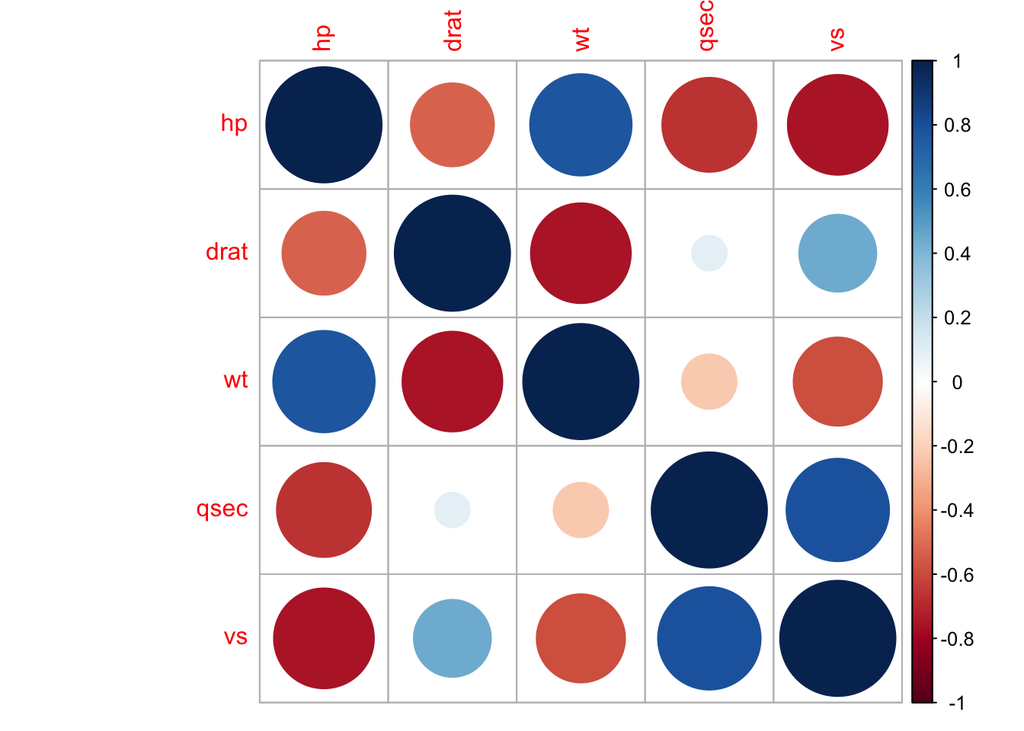

```r
# install.packages("corrplot")
library(corrplot)
mycorrs <- cor(mtcars[,4:8], use="complete.obs", method="spearman")
corrplot(mycorrs)
```

Othertimes so-called **heat maps** are useful to quickly spot clusters of associations amongst many variables.

For a famous example, check out the paper “Matching Categorical Object Representations in Inferior Temporal Cortex of Man and Monkey”, published in *Neuron* by Kriegeskorte and colleagues (2008)

[figure not shown]

Now let’s do our own (slightly less fancy) heat map with the `mtcars` dataset

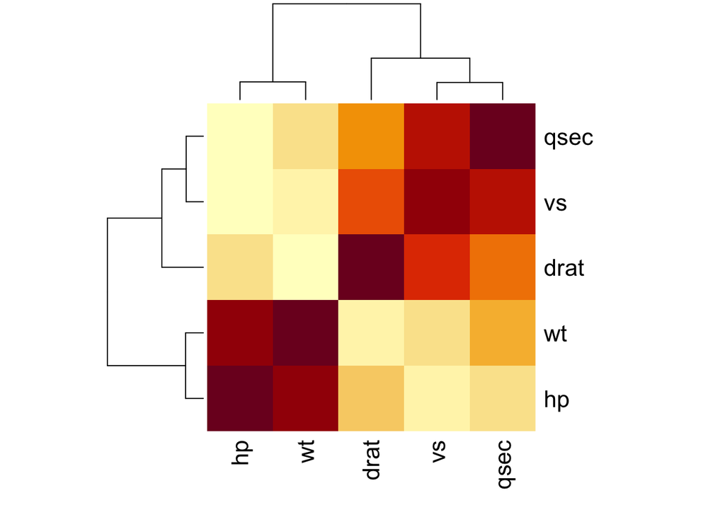

```r
mycorrs <- cor(mtcars[,4:8], use="complete.obs", method="spearman")
heatmap(mycorrs)
```

# Student’s t-test

The t-test allows us to test

- if the average of a variable differs significantly from a specific number (One-sample t-test)
- if two groups of subjects differ from each other (Independent-samples t-test)
- if two measures, which were taken on the same group of subjects, differ from each other (Paired-samples t-test)

It is important to remember, that with a t-test you can only compare a max of 2 groups, or 2 conditions. Use ANOVA or linear mixed models if you have more groups and/or conditions.

By default, the function `t.test()` assumes unequal variances and applies the Welsh degrees of freedom (df) modification. To specify equal variances, use the `var.equal = TRUE` option.

## One-sample t-test

- For testing if the mean of a sample differs significantly from 0 (or any other number).

For example, we could test if the average horse power of all cars in the dataset mtcars differs from 0 (which it does), and from 150 (which it doesn’t)

```r
t.test(mtcars$hp, mu = 0)
```

```
##
##  One Sample t-test
##
## data:  mtcars$hp
## t = 12.103, df = 31, p-value = 2.794e-13
## alternative hypothesis: true mean is not equal to 0
## 95 percent confidence interval:
##  121.9679 171.4071
## sample estimates:
## mean of x
##  146.6875
```

```r
t.test(mtcars$hp, mu = 150)
```

```
##
##  One Sample t-test
##
## data:  mtcars$hp
## t = -0.2733, df = 31, p-value = 0.7864
## alternative hypothesis: true mean is not equal to 150
## 95 percent confidence interval:
##  121.9679 171.4071
## sample estimates:
## mean of x
##  146.6875
```

## Independent t-test

- For testing the difference between 2 unrelated samples (i.e. different subjects in two groups or conditions - imagine comparing men with women, or drug 1 with drug 2)

Attention: The specification of the formula depends depending on whether your data is in long or wide format

In long format we specify a numeric and a binary factor (separated by “~”):

```r
# select only chicken that followed diets 1 or 2 (we can only compare 2 groups with t-test):
ChickWeight_temp <- ChickWeight[ChickWeight$Diet == 1  |  ChickWeight$Diet == 2, ]

# average across chicken by time and diet
ChickWeight_temp_long <- aggregate(ChickWeight_temp, by=list(ChickWeight_temp$Time, ChickWeight_temp$Diet), FUN = mean, na.rm = TRUE)

# make a bit nicer
ChickWeight_temp_long <- ChickWeight_temp_long[, c(1:3)]
colnames(ChickWeight_temp_long)[1:2] <- c("Time", "Diet")

# now test if weight differs between diet 1 and 2
t.test(ChickWeight_temp_long$weight ~ as.factor(ChickWeight_temp_long$Diet) )
```

```
##
##  Welch Two Sample t-test
##
## data:  ChickWeight_temp_long$weight by as.factor(ChickWeight_temp_long$Diet)
## t = -0.74786, df = 20.988, p-value = 0.4628
## alternative hypothesis: true difference in means is not equal to 0
## 95 percent confidence interval:
##  -63.98631  30.13885
## sample estimates:
## mean in group 1 mean in group 2
##        105.6929        122.6167
```

Assume equal variances (this changes the dfs, and slightly the p value):

```r
t.test(ChickWeight_temp_long$weight ~ as.factor(ChickWeight_temp_long$Diet), var.equal = TRUE )
```

```
##
##  Two Sample t-test
##
## data:  ChickWeight_temp_long$weight by as.factor(ChickWeight_temp_long$Diet)
## t = -0.74786, df = 22, p-value = 0.4625
## alternative hypothesis: true difference in means is not equal to 0
## 95 percent confidence interval:
##  -63.85473  30.00727
## sample estimates:
## mean in group 1 mean in group 2
##        105.6929        122.6167
```

Change to 1-tailed t-test (modifies the *p* value)

```r
t.test(ChickWeight_temp_long$weight ~ as.factor(ChickWeight_temp_long$Diet), var.equal = TRUE, alternative="less")
```

```
##
##  Two Sample t-test
##
## data:  ChickWeight_temp_long$weight by as.factor(ChickWeight_temp_long$Diet)
## t = -0.74786, df = 22, p-value = 0.2312
## alternative hypothesis: true difference in means is less than 0
## 95 percent confidence interval:
##      -Inf 21.93463
## sample estimates:
## mean in group 1 mean in group 2
##        105.6929        122.6167
```

```r
t.test(ChickWeight_temp_long$weight ~ as.factor(ChickWeight_temp_long$Diet), var.equal = TRUE, alternative="greater")
```

```
##
##  Two Sample t-test
##
## data:  ChickWeight_temp_long$weight by as.factor(ChickWeight_temp_long$Diet)
## t = -0.74786, df = 22, p-value = 0.7688
## alternative hypothesis: true difference in means is greater than 0
## 95 percent confidence interval:
##  -55.78209       Inf
## sample estimates:
## mean in group 1 mean in group 2
##        105.6929        122.6167
```

Now let’s put the same data in wide format, to compare 2 numeric factors (separated by “,”):

```r
library(reshape2)
ChickWeight_temp_wide <-  dcast(ChickWeight_temp_long, Time ~ Diet , value.var = "weight")
colnames(ChickWeight_temp_wide)[2:3] <- c("Diet1", "Diet2")
t.test(ChickWeight_temp_wide$Diet1 , ChickWeight_temp_wide$Diet2 )
```

```
##
##  Welch Two Sample t-test
##
## data:  ChickWeight_temp_wide$Diet1 and ChickWeight_temp_wide$Diet2
## t = -0.74786, df = 20.988, p-value = 0.4628
## alternative hypothesis: true difference in means is not equal to 0
## 95 percent confidence interval:
##  -63.98631  30.13885
## sample estimates:
## mean of x mean of y
##  105.6929  122.6167
```

It is important to point out that you get the same *t* and *p* values and dfs using the data in long or wide format!

## Dependent (paired-sample) t-test

- For testing difference between two related samples (i.e. same people tested twice)

We could use the same ChickenWeight data, but this time compare identical chicken across 2 time points.

IMPORTANT: add the option PAIRED

In long format we specify a numeric and a binary factor (separated by “~”):

```r
# select only Time 1 and 2:
ChickWeight_temp <- ChickWeight[ChickWeight$Time <= 2,]
t.test(ChickWeight_temp$weight ~ as.factor(ChickWeight_temp$Time), paired=TRUE )
```

```
##
##  Paired t-test
##
## data:  ChickWeight_temp$weight by as.factor(ChickWeight_temp$Time)
## t = -15.907, df = 49, p-value < 2.2e-16
## alternative hypothesis: true difference in means is not equal to 0
## 95 percent confidence interval:
##  -9.190877 -7.129123
## sample estimates:
## mean of the differences
##                   -8.16
```

In the wide format, we specify 2 numeric factors (separated by “,”)

```r
library(reshape2)
ChickWeight_temp <- ChickWeight[ChickWeight$Time <= 2,]
ChickWeight_temp_wide <-  dcast(ChickWeight_temp, Chick + Diet ~ Time, value.var = "weight")
colnames(ChickWeight_temp_wide)[3:4] <- c("time0", "time2")
t.test(ChickWeight_temp_wide$time0 , ChickWeight_temp_wide$time2, paired=TRUE )
```

```
##
##  Paired t-test
##
## data:  ChickWeight_temp_wide$time0 and ChickWeight_temp_wide$time2
## t = -15.907, df = 49, p-value < 2.2e-16
## alternative hypothesis: true difference in means is not equal to 0
## 95 percent confidence interval:
##  -9.190877 -7.129123
## sample estimates:
## mean of the differences
##                   -8.16
```

## Mann-Whitney U & Wilcoxon signed ranks tests

One of the assumptions of the t-test, is that the data are normally distributed. However, even in cases when the data is NOT normally distributed, one can use the t-test as long as the sample size is reasonably large: N at least >10, better >100. Thus, the t-test is quite robust for violations of the normality assumption, as long as the sample is not too small.

An alternative to the t-test exists , which does not require normal distribution of the data:

The non-parametric *Mann-Whitney U* test (also called Mann-Whitney-Wilcoxon, Wilcoxon rank-sum, or Wilcoxon-Mann-Whitney test) can be used as alternative to the *independent t-test*.

It is calculated in 2 different ways, depending on the sample size (<20 or >20). In any case, it involves some ranking of the values of both groups, and does not assume normal distribution of the data.

The *Wilcoxon signed ranks* test can be used as an alternative to the *dependent t-test*

Implementation of these nonparametric tests is easy, and the formula almost identical to the t-test one.

Here an example of the Mann-Whitney U test:

```r
# select again only chicken that followed diets 1 or 2 (we can only compare 2 groups with t-test or Mann-Whitney):
ChickWeight_temp <- ChickWeight[ChickWeight$Diet == 1  |  ChickWeight$Diet == 2, ]
wilcox.test(ChickWeight_temp[,1] , ChickWeight_temp[,2])
```

```
##
##  Wilcoxon rank sum test with continuity correction
##
## data:  ChickWeight_temp[, 1] and ChickWeight_temp[, 2]
## W = 115600, p-value < 2.2e-16
## alternative hypothesis: true location shift is not equal to 0
```

And here an example of the Wilcoxon signed ranks test:

```r
# select only Time 1 and 2 (applied to all chicken):
ChickWeight_temp <- ChickWeight[ChickWeight$Time <= 2,]
# put Time in wide format
library(reshape2)
ChickWeight_temp_wide <-  dcast(ChickWeight_temp, Chick + Diet ~ Time, value.var = "weight")
colnames(ChickWeight_temp_wide)[3:4] <- c("time0", "time2")
# perform statistics:
wilcox.test(ChickWeight_temp_wide$time0 , ChickWeight_temp_wide$time2, paired=TRUE )
```

```
##
##  Wilcoxon signed rank test with continuity correction
##
## data:  ChickWeight_temp_wide$time0 and ChickWeight_temp_wide$time2
## V = 8, p-value = 1.132e-09
## alternative hypothesis: true location shift is not equal to 0
```

# Linear models (regression)

## Simple regression

A simple linear regression is similar to a correlation: You want to know the link between two variables. In a regression, however, you go further than in a correlation, as you want to know how much Y depends on (is predicted by) X.

A regression therefore tries to predict changes in the dependent variable (DV, the thing you measured) based on 1 or more independent variables (IVs, predictors), even for a range of the IV that is yet unknown.

For example, the “mtcars” dataset includes cars that have between 52 and 335 horse power. By fitting a regression model with miles per gallon (mpg) as DV, and horse power (hp) as IV, we can try to predict what the mpg would be for a car with 400 hp.

The mathematical formula for a simple linear regression is  
`y = b0 + b1*x1 + error`

Where:

- y (actually y-hat) is the predicted value of the DV (e.g. mpg)
- x1 is an IV or predictor (e.g. hp)
- b0 is the intercept of the regression line
- b1 is the slope of the regression line
- and the rest is the error of the model

How does linear regression operate?:  
The b values (also called regression coefficients) are estimated based on the principle of the least squares. A regression model gives you the line of best fit, i.e. the one that has the smallest overall distance from all the data points. The (vertical) distances between the line and data points are called `residuals`. The principle of the least squares means that the sum of the squared residuals needs to be as small as possible.

The commands you need to type into R to carry out a linear regression are:  
`lm(DV ~ IV, yourdata)`  
where DV is the dependent variable (what you measured), and IV the independent one (the factor partly explaining or predicting the DV). Get the result using `summary()`, or `anova()`.

Let’s test if the horsepower of cars predicts their gas consumption (in mpg):

```r
model1 <- lm(mpg ~ hp, mtcars)
summary(model1)
```

```
##
## Call:
## lm(formula = mpg ~ hp, data = mtcars)
##
## Residuals:
##     Min      1Q  Median      3Q     Max
## -5.7121 -2.1122 -0.8854  1.5819  8.2360
##
## Coefficients:
##             Estimate Std. Error t value Pr(>|t|)
## (Intercept) 30.09886    1.63392  18.421  < 2e-16 ***
## hp          -0.06823    0.01012  -6.742 1.79e-07 ***
## ---
## Signif. codes:  0 '***' 0.001 '**' 0.01 '*' 0.05 '.' 0.1 ' ' 1
##
## Residual standard error: 3.863 on 30 degrees of freedom
## Multiple R-squared:  0.6024, Adjusted R-squared:  0.5892
## F-statistic: 45.46 on 1 and 30 DF,  p-value: 1.788e-07
```

How to read the output:

**R-squared (R2)** informs us about the amount of variance of mpg that is explained by the model (in this case 60%). Since a simple regression only includes 1 IV, R2 also represents how much variance is explained by hp. If you take the square root of R2, you get the Pearson correlation coefficient *r*: `sqrt(0.6024) = 0.77` Thus, there is a strong correlation between mpg and hp.

The **Adjusted R2** indicates how well the model generalizes to the population. This value should be close to R2, but is typically a bit smaller. The adjusted R-squared also adjusts for the fact that models with more IVs (see multiple regression) will automatically have a greater R2.

The significant F-Statistic in the last line informs us that the model predicts well the DV. Since the model only includes 1 IV, the F-Statistic in this case also tells us that hp is a good predictor of mpg.

The most important part of the output is the **Coefficients** table:

- the estimate in the first line (**Intercept**), gives the intercept of the model’s line, i.e. how many miles per gallon you could drive if your car had 0 horse power: 30! (our model obviously doesn’t understand much of cars, otherwise it would know that a car with 0 hp does not drive at all)
- The line starting with “hp” gives: the estimate of how much mpg changes for 1-point change in hp (it is the **slope**, or gradient, of the line best representing the data). The *t* value indicates the magnitude of the IV’s effect, and the *p* value its statistical significance. Notice that the estimate for hp is negative, because indeed there is a negative relation between mpg and hp: the stronger the car, the fewer mpg of gas you can drive. The estimate also tells us that for every additional horse power you lose 0.068 mpg. Thus, a car with 400 hp would have 2.8 mpg (the result of 30.09886 - (0.06823 * 400)).

Let’s verify these things by plotting the scatterplot with the fitted regression line. To have the line extend all the way from 0 to 400 hp, we need to include `xlim(0,400)` and the `fullrange=TRUE` option.

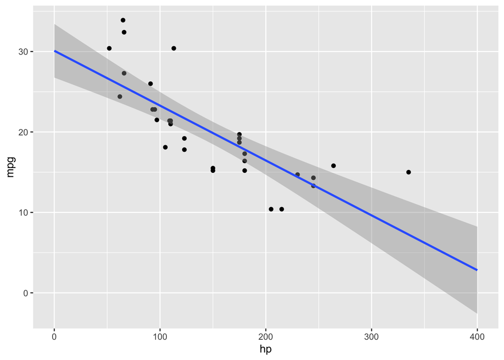

```r
library(ggplot2)
ggplot(mtcars, aes(x = hp, y = mpg)) +
  geom_point() +
  xlim(0, 400) +
  stat_smooth(method = "lm", fullrange=TRUE)
```

In the summary of the regression model, the 3rd line from the bottom provides the **degrees of freedom** (df = 30).

Plotting a simple linear regression is easy using the `stat_smooth(method = "lm")` command (see above).  
But we could also add the regression line using the command `geom_abline()`, and by specifying by hand the intercept and slope of the line.

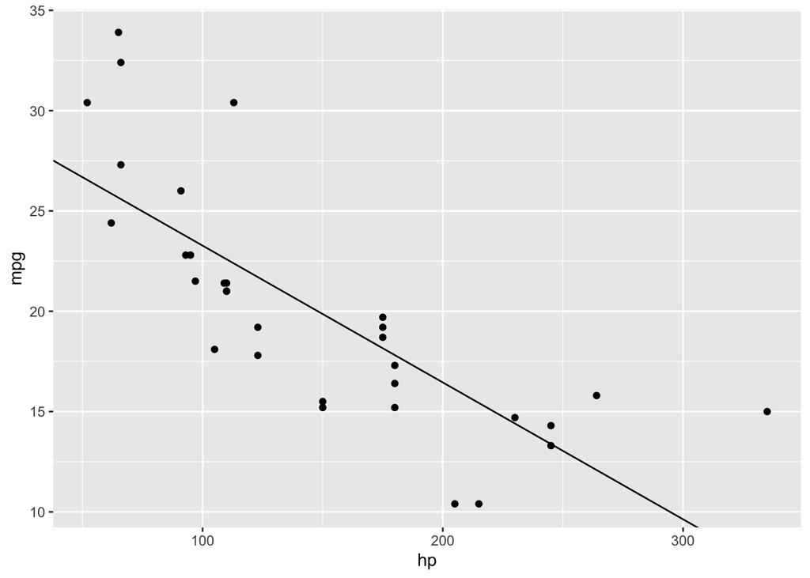

```r
ggplot(mtcars,aes(y=mpg,x=hp))+
  geom_point()+
  geom_abline(color = "black", linetype = "solid", intercept = coefficients(model1)[1], slope = coefficients(model1)[2])
```

Moreover, we could extract the values predicted by the model, together with the confidence interval.

```r
head(predict(model1,interval="confidence"))
```

```
##                        fit      lwr      upr
## Mazda RX4         22.59375 21.00634 24.18116
## Mazda RX4 Wag     22.59375 21.00634 24.18116
## Datsun 710        23.75363 21.97149 25.53578
## Hornet 4 Drive    22.59375 21.00634 24.18116
## Hornet Sportabout 18.15891 16.64651 19.67131
## Valiant           22.93489 21.29561 24.57417
```

These predicted points and the regression line + confidence interval are shown in the following plot:

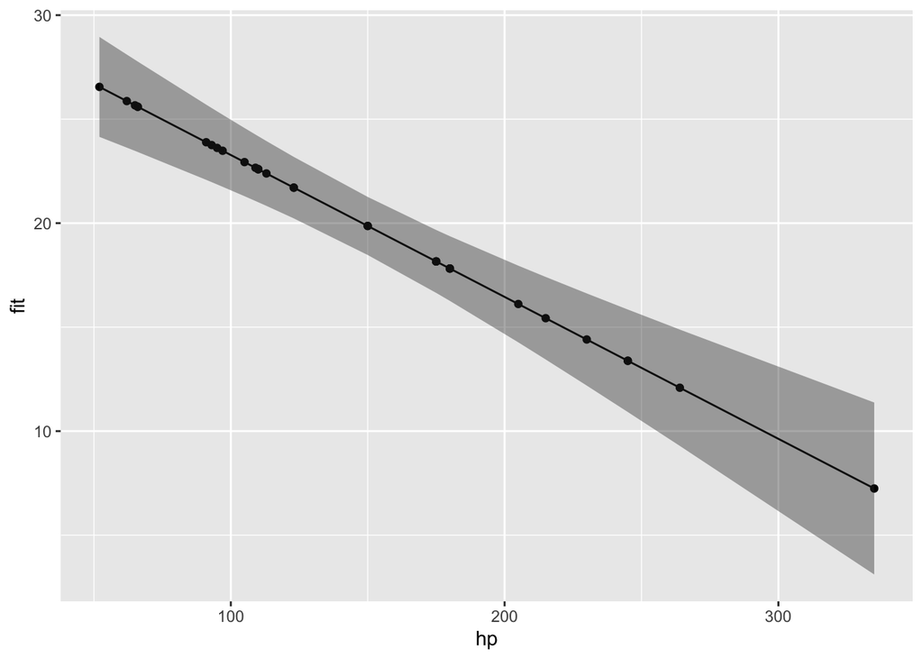

```r
mtcars<-cbind(mtcars,predict(model1,interval="confidence"))
ggplot(mtcars,aes(y=fit,x=hp))+geom_point()+
  geom_line(aes(y=fit))+geom_ribbon(aes(ymin=lwr,ymax=upr),alpha=0.4)
```

**How to report the results of a linear regression:**  
The statistics can be reported like this: hp significantly predicted mpg, as confirmed by linear regression (*t*(30) = -6.742, *p* < .001, R-squared = .6).

## Multiple regression

Multiple regressions include more than one predictor (or IV). There are several ways in which you can enter these predictors in the model.

In multiple regression without interaction, you look at the main (or simple) effects of each predictor taking into consideration the other predictors, but you do not specify interactions between the effects. In the commands to run multiple regression without interaction, the different predictors are separated by “+” only.

In multiple regression with interaction, you also want to investigate if the predictors interact with each other.

If you have more than 2 predictors, you can either look at all the main and interaction effects, or specify only certain interactions. The "*" sign specifies main and interaction effects of the 2 IVs on each side of the star. The “:” sign specifies only the interaction of the 2 IVs on each side of the colon.

The table shows you how to write the corresponding formulas.

|  | Number of effects | Formula |
| --- | --- | --- |
| a | 3 main effects | IV1 + IV2 + IV3 |
| b | 3 main effects and 1 2-way interaction | IV1 * IV2 + IV3 |
| c | Alternative writing of model “b” | IV1 + IV2 + IV1:IV2 + IV3 |
| d | 3 main effects and 2 2-way interactions | IV1 + IV2 + IV3 + IV1:IV2 + IV1:IV3 |
| e | 3 main effects, 3 2-way interactions and 1 3-way interaction | IV1 * IV2 * IV3 |
| f | Alternative writing of model “e” | IV1+IV2+IV3+IV1:IV2+IV1:IV3+IV2:IV3+IV1:IV2:IV3 |

And these are the models using mpg as DV and hp, cyl, and disp as IVs.

```r
model_a <- lm(mpg ~ hp + cyl + disp, mtcars)
model_b <- lm(mpg ~ hp * cyl + disp, mtcars)
model_c <- lm(mpg ~ hp + cyl + hp : cyl + disp, mtcars)
model_d <- lm(mpg ~ hp + cyl + disp + hp : cyl + hp : disp, mtcars)
model_e <- lm(mpg ~ hp * cyl * disp, mtcars)
model_f <- lm(mpg ~ hp + cyl + disp + hp:cyl + hp:disp + cyl:disp + hp:cyl:disp, mtcars)
```

## Multiple regression without interaction

The mathematical formula for multiple regression without interaction includes 2 or more predictors  
`y = b0 + b1*x1 + b2*x2 + error`

Where:

- y (actually y-hat) is the predicted value of the DV (e.g. mpg)
- x1 is the first IV or predictor (e.g. hp)
- x2 is the second IV or predictor (e.g. cyl)
- b0 is the intercept
- b1 is the slope for x1
- b2 is the slope for x2
- and the rest is the error of the model

A more complicated model, that icludes several predictors, could help explain more variance, and thus achieve a greater R-squared.

You can compare the fit (R2) of different regression models using the function `anova()`.

So when regressing mpg onto hp, do we explain more variance by also including the car’s cylinders?

```r
model1 <- lm(mpg ~ hp, mtcars)
model2 <- lm(mpg ~ hp + factor(cyl), mtcars)
anova(model1, model2)
```

```
## Analysis of Variance Table
##
## Model 1: mpg ~ hp
## Model 2: mpg ~ hp + factor(cyl)
##   Res.Df    RSS Df Sum of Sq      F   Pr(>F)
## 1     30 447.67
## 2     28 277.17  2    170.51 8.6124 0.001216 **
## ---
## Signif. codes:  0 '***' 0.001 '**' 0.01 '*' 0.05 '.' 0.1 ' ' 1
```

Yes we do. The comparison of the 2 models showed that model2 fits better to the data. The adjusted R2 of the 2nd model (the more complex one that includes 2 predictors) is 0.73, and thus significantly bigger than for the 1st model (0.59).

```r
c("adj R2 mod1: ", round( summary(model1)$adj.r.squared, digits=2) )
```

```
## [1] "adj R2 mod1: " "0.59"
```

```r
c("adj R2 mod2: ", round( summary(model2)$adj.r.squared, digits=2) )
```

```
## [1] "adj R2 mod2: " "0.73"
```

By using multiple instead of simple regression, we were able to explain 14% more variance! Here the summary of model2.

```r
summary(model2)
```

```
##
## Call:
## lm(formula = mpg ~ hp + factor(cyl), data = mtcars)
##
## Residuals:
##    Min     1Q Median     3Q    Max
## -4.818 -1.959  0.080  1.627  6.812
##
## Coefficients:
##              Estimate Std. Error t value Pr(>|t|)
## (Intercept)  28.65012    1.58779  18.044  < 2e-16 ***
## hp           -0.02404    0.01541  -1.560  0.12995
## factor(cyl)6 -5.96766    1.63928  -3.640  0.00109 **
## factor(cyl)8 -8.52085    2.32607  -3.663  0.00103 **
## ---
## Signif. codes:  0 '***' 0.001 '**' 0.01 '*' 0.05 '.' 0.1 ' ' 1
##
## Residual standard error: 3.146 on 28 degrees of freedom
## Multiple R-squared:  0.7539, Adjusted R-squared:  0.7275
## F-statistic: 28.59 on 3 and 28 DF,  p-value: 1.14e-08
```

Notice that we now have 2 coefficients relating to the predictor `cyl`: 1 called factor(cyl)6 and the other factor(cyl)8.

Keep in mind that there are also cars with 4 cylinders, which however are not mentionned in the coefficients. How come?

This is because R has automatically chosen 4 to be the first (base) level of the factor cyl. The other levels (6 and 8) are compared to level 4. The base level of a factor is chosen either alphabetically, or on the smallest number (4 < 6 & 4 < 8).

You can verify the order of levels of a factor (and you could change it too):

```r
levels(factor(mtcars$cyl))
```

```
## [1] "4" "6" "8"
```

So what do these coefficients mean, and how do we use them to plot the results of the regression?

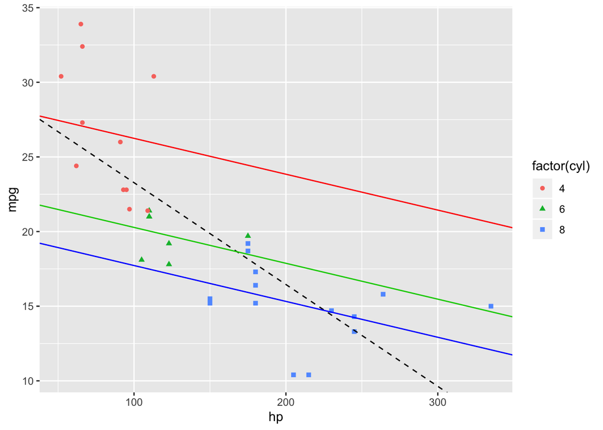

```r
ggplot(mtcars,aes(y=mpg,x=hp,color=factor(cyl), shape=factor(cyl)))+
  geom_point()+
  geom_abline(color = "black", linetype = "dashed", intercept = coefficients(model1)[1], slope = coefficients(model1)[2]) +
  geom_abline(color="green3", intercept = coefficients(model2)[1] + coefficients(model2)[3], slope = coefficients(model2)[2]) +
  geom_abline(color="blue", intercept = coefficients(model2)[1] + coefficients(model2)[4], slope = coefficients(model2)[2]) +
  geom_abline(color="red", intercept = coefficients(model2)[1] , slope = coefficients(model2)[2])
```

Which of the 2 predictors in model 2 is more important ?  
To answer that question, we can look at their estimates, SEs, and t-values:

```r
summary(model2)$coefficients
```

```
##                 Estimate Std. Error   t value     Pr(>|t|)
## (Intercept)  28.65011816  1.5877870 18.044056 5.921199e-17
## hp           -0.02403883  0.0154079 -1.560163 1.299540e-01
## factor(cyl)6 -5.96765508  1.6392776 -3.640418 1.092089e-03
## factor(cyl)8 -8.52085075  2.3260749 -3.663188 1.028617e-03
```

Only cyl significantly predicts mpg, as indicated by the *p* values in the 2 lowest rows being < .05 (the numbers are to the negative power of 3!). The *p* value for hp is only .13. Therefore, the number of cylinders of a car has a bigger effect on gas consumption than horse power.

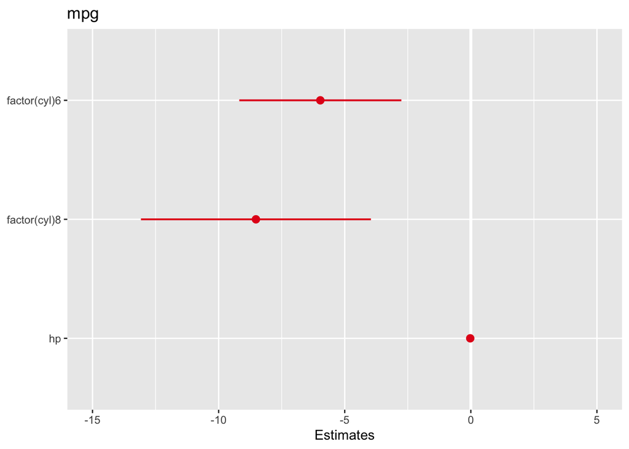

```r
library(sjPlot)
plot_model(model2)
```

So far we have used `summary()` to see the coefficients of model 2.  
We observed that both the line for 6 and for 8 cylinder cars are significantly lower than the line for 4 cylinder cars (the respective *t* values are -3.64 and -3.66, and the *p* values are .001 in both cases). The effect of hp was not significant (*p* = .13).

However, you might be more familiar with the **ANOVA output**, which tells us if the factor cylinder predicts mpg in general (as opposed to the specific comparisons of 4-6 and 4-8 cylinder cars). In other words, the anova table provides a test of the factor as a whole, while the summary provides tests of individual levels against the reference level.

**CAREFUL**: for multiple regression ALWAYS use the function **`Anova()`** (with capital A!!) from the package `car`, and NEVER use `anova()` (with small caps a), which can lead to absolutely wrong results.  
Moreover, for models with interaction specify “type = 3” (while for models without interaction it doesn’t matter if type = 2 or 3 - see [here](https://www.r-bloggers.com/anova-%E2%80%93-type-iiiiii-ss-explained/) and [here](https://rcompanion.org/rcompanion/d_04.html) for an explanation).

```r
library(car)
Anova(model2, type = 3)
```

```
## Anova Table (Type III tests)
##
## Response: mpg
##             Sum Sq Df  F value    Pr(>F)
## (Intercept) 3222.9  1 325.5880 < 2.2e-16 ***
## hp            24.1  1   2.4341  0.129954
## factor(cyl)  170.5  2   8.6124  0.001216 **
## Residuals    277.2 28
## ---
## Signif. codes:  0 '***' 0.001 '**' 0.01 '*' 0.05 '.' 0.1 ' ' 1
```

## Multiple regression with interaction

Although the intercepts of the 3 regression lines in model 2 differ, their slopes are still the same (the lines are perfectly parallel).

However, if we include an interaction term in the model, we will also allow for the slopes to vary.

The mathematical formula including an interaction term could look like this:  
`y = b0 + b1*x1 + b2*x2 + b3*x1*x2 + error`

Where:

- y is the predicted value of the DV (mpg)
- x1 is the first IV or predictor (hp)
- x2 is the second IV or predictor (cyl)
- x1*x2 is the interaction term
- b0 is the intercept
- b1 is the slope for x1
- b2 is the slope for x2
- b3 is the slope for the interaction of x1*x2
- and the rest is the error of the model

To run this model in R we simply replace the + (sum) sign between hp and cyl with a * (multiplication) sign.

```r
# model1 <- lm(mpg ~ hp, mtcars)
# model2 <- lm(mpg ~ hp + factor(cyl), mtcars)
model3 <- lm(mpg ~ hp * factor(cyl), mtcars)
```

Let’s plot the regression lines for model 3 (the black dashed line is from model 1).

Now both the intercepts and the slopes for the cars with 4,6, and 8 cylinders are allowed to vary.

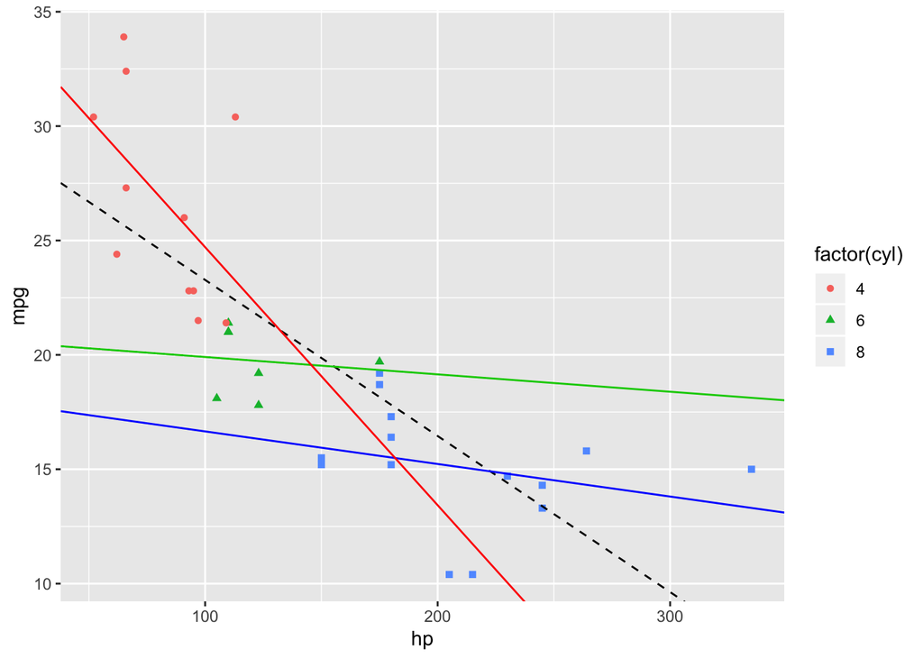

```r
ggplot(mtcars,aes(y=mpg,x=hp,color=factor(cyl), shape=factor(cyl)))+
  geom_point()+
  geom_abline(color = "black", linetype = "dashed", intercept = coefficients(model1)[1], slope = coefficients(model1)[2]) +
  geom_abline(color="green3", intercept = coefficients(model3)[1] + coefficients(model3)[3], slope = coefficients(model3)[2] + coefficients(model3)[5]) +
  geom_abline(color="blue", intercept = coefficients(model3)[1] + coefficients(model3)[4], slope = coefficients(model3)[2] + coefficients(model3)[6]) +
  geom_abline(color="red", intercept = coefficients(model3)[1] , slope = coefficients(model3)[2])
```

But back to the question of significance in model 3.  
Is mpg significantly predicted by hp? and by cyl? and by the interaction of hp and cyl?

We could try to answer these questions by using the `summary()` function.  
However, as soon as factors have several levels, things start to look complicated.

The Anova output of model 3 looks clearer, and shows that both hp and cyl influence mpg, but not in interaction with each other. Remember to specify type = 3 (see [here](https://www.r-bloggers.com/anova-%E2%80%93-type-iiiiii-ss-explained/) and [here](https://rcompanion.org/rcompanion/d_04.html) for an explanation).

```r
car::Anova(model3, type=3)
```

```
## Anova Table (Type III tests)
##
## Response: mpg
##                Sum Sq Df F value    Pr(>F)
## (Intercept)    785.15  1 85.6056 1.042e-09 ***
## hp              55.74  1  6.0773  0.020614 *
## factor(cyl)    112.21  2  6.1173  0.006648 **
## hp:factor(cyl)  38.70  2  2.1099  0.141533
## Residuals      238.46 26
## ---
## Signif. codes:  0 '***' 0.001 '**' 0.01 '*' 0.05 '.' 0.1 ' ' 1
```

Why is there no significant interaction, since the figure shows quite different slopes for the lines passing through cars with 4 cylinders and the other 2 types of cars?

The reason is the great amount of variance, which is in part due to the small number of cars in each group.  
This becomes visible if we add confidence intervals to the plot.  
The graph on the right looks even worse, as we extend regression lines to areas without cars of that type, which widens CIs even more.

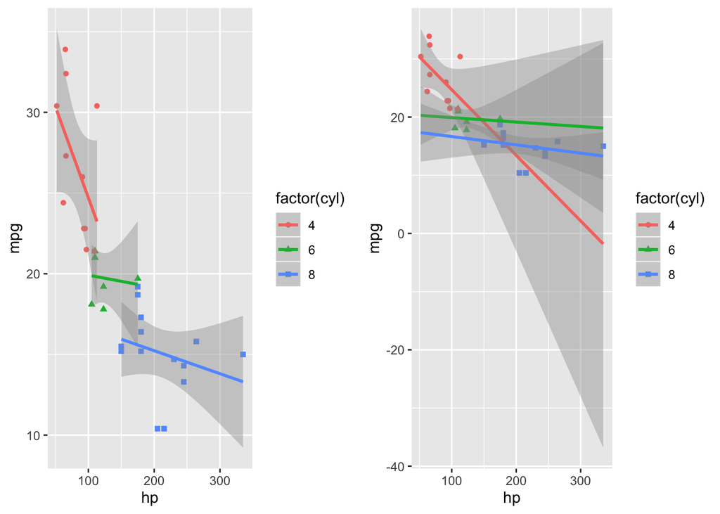

```r
p1 <- ggplot(mtcars, aes(x = hp, y = mpg,color=factor(cyl), shape=factor(cyl))) +
  geom_point()  +
  stat_smooth(method = "lm")
p2 <- ggplot(mtcars, aes(x = hp, y = mpg,color=factor(cyl), shape=factor(cyl))) +
  geom_point()  +
  stat_smooth(method = "lm",  fullrange=TRUE)
cowplot::plot_grid(p1, p2)
```

## Plot regression effects

We saw before, that regression models with and without interaction can be plotted using `ggplot()`, and specifying the intercepts and slopes by hand.

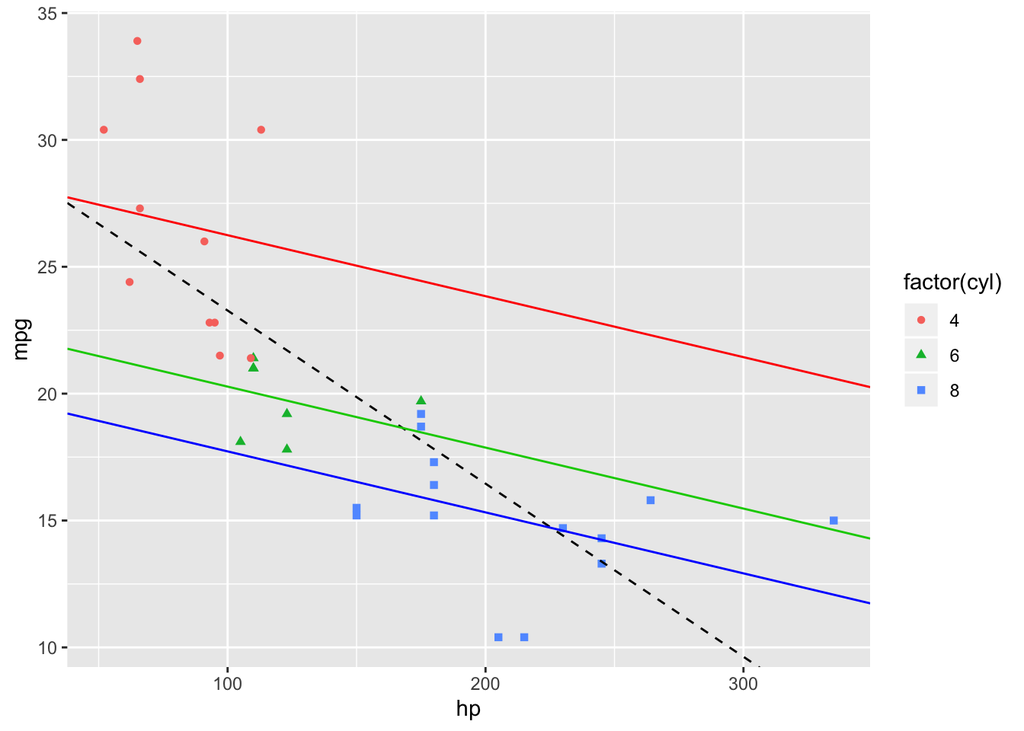

```r
model1 <- lm(mpg ~ hp, mtcars)
model2 <- lm(mpg ~ hp + factor(cyl), mtcars)
library(ggplot2)
ggplot(mtcars,aes(y=mpg,x=hp,color=factor(cyl), shape=factor(cyl)))+
  geom_point()+
  geom_abline(color = "black", linetype = "dashed", intercept = coefficients(model1)[1], slope = coefficients(model1)[2]) +
  geom_abline(color="green3", intercept = coefficients(model2)[1] + coefficients(model2)[3], slope = coefficients(model2)[2]) +
  geom_abline(color="blue", intercept = coefficients(model2)[1] + coefficients(model2)[4], slope = coefficients(model2)[2]) +
  geom_abline(color="red", intercept = coefficients(model2)[1] , slope = coefficients(model2)[2])
```

You can also add the regression line(s) with `stat_smooth(method = "lm")`. However, for multilpe regression this command will always plot the results including interaction terms (no parallel slopes plots).

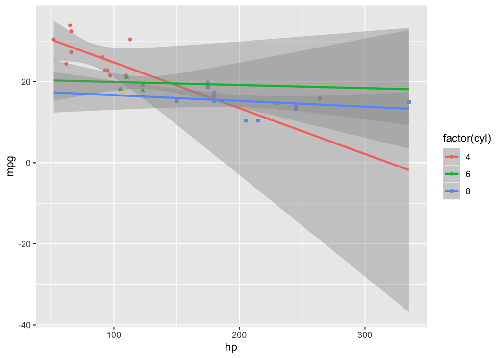

```r
ggplot(mtcars,aes(y=mpg,x=hp,color=factor(cyl), shape=factor(cyl)))+
  geom_point()+
  stat_smooth(method = "lm", fullrange=TRUE)
```

Here for the model with the interaction term

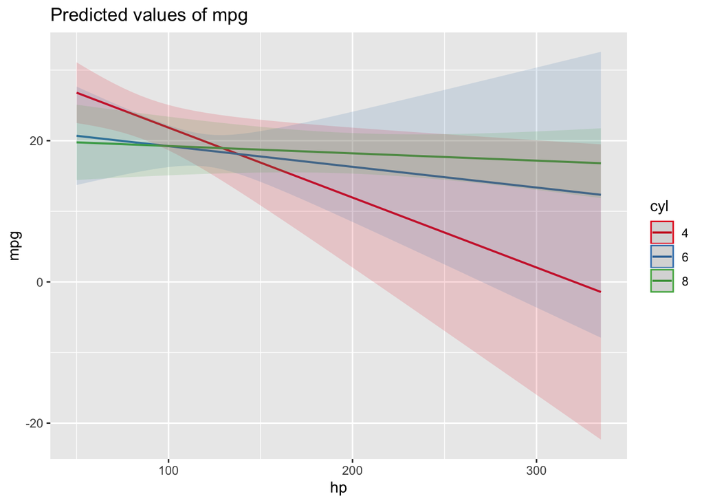

```r
library(sjPlot)
model3 <- lm(mpg ~ hp * factor(cyl) + disp, mtcars)
plot_model(model3, type = "pred", terms = c("hp",  "cyl") )
```

And here with 3 IVs (and all interaction terms):

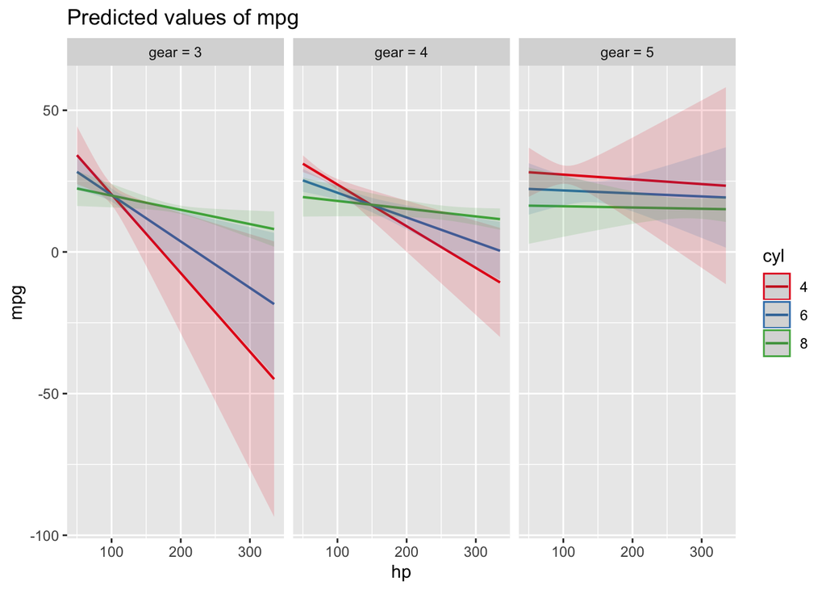

```r
library(sjPlot)
model4 <- lm(mpg ~ hp * cyl * gear, mtcars)
plot_model(model4, type = "pred", terms = c("hp", "cyl", "gear") )
```

Another commonly used one is the package `effects()`

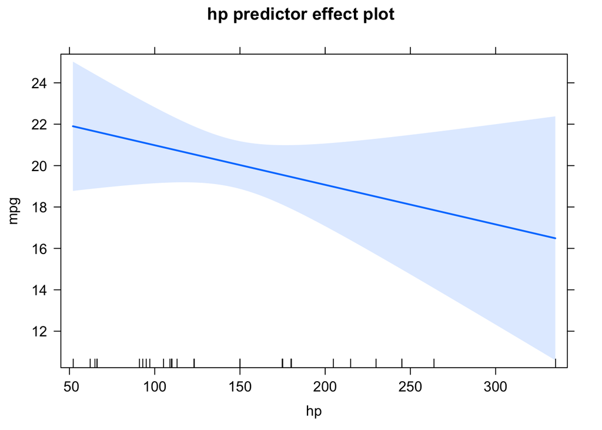

```r
library(effects)
model2 <- lm(mpg ~ hp + cyl, mtcars)
plot(predictorEffect("hp", model2))
```

Also check out function `effect_plot()` from package `jtools`

## Assumptions for linear regression

There are a number of assumption the linear regression model will make about the data.

### Linearity

Plot the model’s residuals (the distances from each data point to the fitted regression line), which ideally should be equally distributed around the horizontal line. If they aren’t, the assumption of linearity might be violated. In that case, try transforming the data, e.g. with a log-transform. Or maybe you missed some important factor (DV) in the model.

To inspect the residuals, you can plot them against the fitted values:

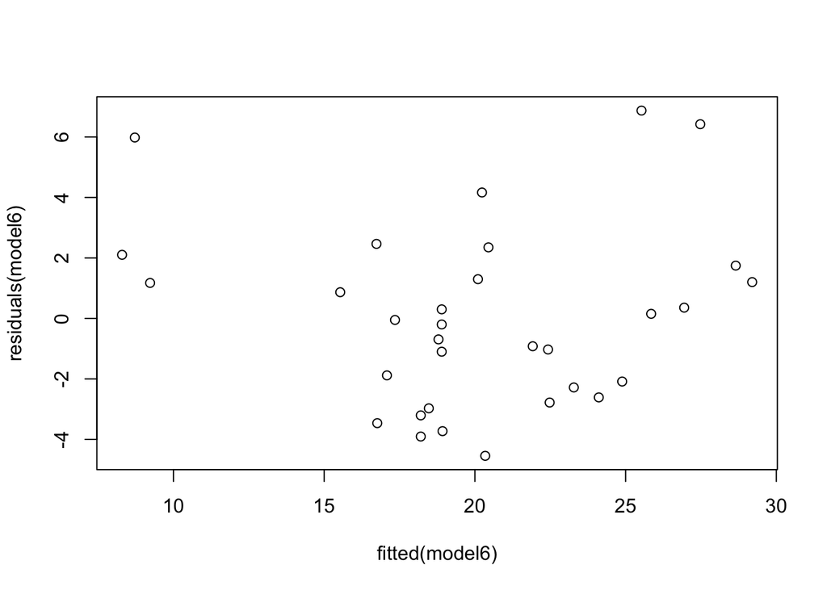

```r
# rm(mtcars) # delete the mtcars in the environment
model6 <- lm(mpg ~ wt, mtcars)
plot(fitted(model6),residuals(model6))
```

Or plot the residuals agains the actual data:

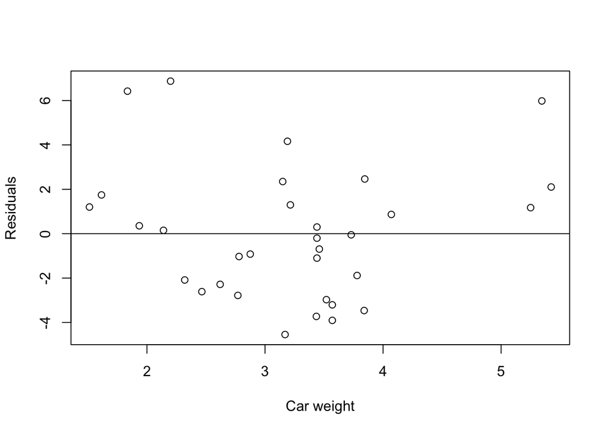

```
## integer(0)
```

```r
model6 <- lm(mpg ~ wt, mtcars)
model6_res = resid(model6)
plot(mtcars$wt, model6_res, ylab="Residuals", xlab="Car weight" ) + abline(0, 0)
```

### Absence of collinearity

Collinearity basically means that 2 or more of the IVs are highly correlated with each other. This can be problematic for the model, and its interpretation. It also means that will deal with larger standard errors and confidence intervals, resulting in fewer chances to reject H0.

One (approximate) way to check for possible collinearity, is to see if some of the IVs in the model are highly correlated. For that, create a pair-wise correlation plot.

```r
rm(mtcars)
round(cor(mtcars[, c(2:4, 6)]), 2) # correlate 4 IVs of interest
```

```
##       cyl disp   hp   wt
## cyl  1.00 0.90 0.83 0.78
## disp 0.90 1.00 0.79 0.89
## hp   0.83 0.79 1.00 0.66
## wt   0.78 0.89 0.66 1.00
```

Or this one which is even nicer

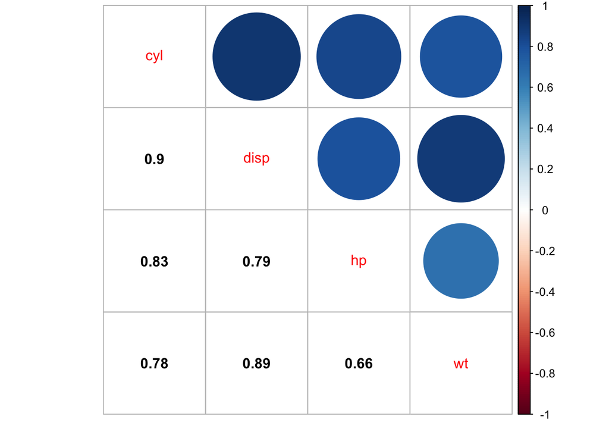

```r
library(corrplot)
cor1 = cor(mtcars[, c(2:4, 6)])
corrplot.mixed(cor1, lower.col = "black")
```

Another sign of possible collinearity is a very high R2, when at the same time most of the coefficients are not significant.

To more formally quantify collinearity you can use the variance inflation factor (VIF). For example, the function `vif()` from the package `car` will compute the VIF of each IV by regressing it onto the other IVs of the model (The actual formual is 1/1-R2 of that IV).

A VIF of over 10 typically indicates high multicollinearity, while a VIF < 4 or 5 indicates acceptable collinearity.

```r
model7 <- lm(mpg ~ cyl + disp + hp + wt, mtcars)
car::vif(model7)
```

```
##       cyl      disp        hp        wt
##  6.737707 10.373286  3.405983  4.848016
```

It seems like the IV “disp” is particularly problematic. The VIFs are all much lower if we remove it from the model.

```r
model8 <- lm(mpg ~ cyl  + hp + wt, mtcars)
car::vif(model8)
```

```
##      cyl       hp       wt
## 4.757456 3.258481 2.580486
```

The Farrar-Glauber test and other model-wide diagnostics measures of collinearity can be computed with the `omcdiag()` function in the `mctest` package

```r
library(mctest)
omcdiag(mtcars[, c(2:4, 6)], mtcars$mpg)
```

```
##
## Call:
## omcdiag(x = mtcars[, c(2:4, 6)], y = mtcars$mpg)
##
##
## Overall Multicollinearity Diagnostics
##
##                        MC Results detection
## Determinant |X'X|:         0.0115         0
## Farrar Chi-Square:       123.9875         1
## Red Indicator:             0.8131         1
## Sum of Lambda Inverse:    25.3650         1
## Theil's Method:            0.7094         1
## Condition Number:         26.8753         0
##
## 1 --> COLLINEARITY is detected by the test
## 0 --> COLLINEARITY is not detected by the test
```

Out of 6 tests, collinearity was detected by 4. This suggests that multicollinearity is likely.

The function imcdiag includes the VIF and 6 other multicollinearity diagnostics, for each IV individually:

```r
library(mctest)
imcdiag(mtcars[, c(2:4, 6)], mtcars$mpg)
```

```
##
## Call:
## imcdiag(x = mtcars[, c(2:4, 6)], y = mtcars$mpg)
##
##
## All Individual Multicollinearity Diagnostics Result
##
##          VIF    TOL      Wi       Fi Leamer    CVIF Klein
## cyl   6.7377 0.1484 53.5519  83.1967 0.3853 -0.5667     1
## disp 10.3733 0.0964 87.4840 135.9126 0.3105 -0.8724     1
## hp    3.4060 0.2936 22.4558  34.8867 0.5418 -0.2864     0
## wt    4.8480 0.2063 35.9148  55.7962 0.4542 -0.4077     0
##
## 1 --> COLLINEARITY is detected by the test
## 0 --> COLLINEARITY is not detected by the test
##
## cyl , disp , hp , coefficient(s) are non-significant may be due to multicollinearity
##
## R-square of y on all x: 0.8486
##
## * use method argument to check which regressors may be the reason of collinearity
## ===================================
```

If you only want the VIF, you can specify so in the call of the formula:

```r
imcdiag(mtcars[, c(2:4, 6)], mtcars$mpg, method="VIF")
```

```
##
## Call:
## imcdiag(x = mtcars[, c(2:4, 6)], y = mtcars$mpg, method = "VIF")
##
##
##  VIF Multicollinearity Diagnostics
##
##          VIF detection
## cyl   6.7377         0
## disp 10.3733         1
## hp    3.4060         0
## wt    4.8480         0
##
## Multicollinearity may be due to disp regressors
##
## 1 --> COLLINEARITY is detected by the test
## 0 --> COLLINEARITY is not detected by the test
##
## ===================================
```

## Homoskedasticity

Another assumption of linear models is that the variance of the data is approximately equal across the range of predicted values.

To check for homo- or heteroskedasticity, plot the residuals against the fitted values. Homoskedasticity is met, if the points in the plot looks like a sort of blob around the horizontal line.

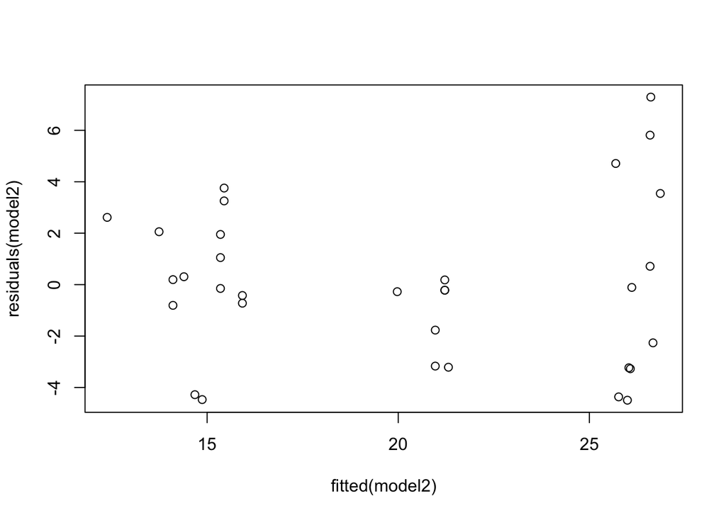

```r
plot(fitted(model2),residuals(model2))
```

You can also check heteroskedasticity with the the Breush-Pagan test and the NCV test. Here, the Breush-Pagan test gives a *p* value slightly above .05 (so the H0 of homoskedasticity is not rejected), but the NCV gives a *p* value just below .05 (in which case we reject H0 and decide that heteroskedasticity is present).

```r
lmtest::bptest(model2)
```

```
##
##  studentized Breusch-Pagan test
##
## data:  model2
## BP = 5.5086, df = 2, p-value = 0.06365
```

```r
car::ncvTest(model2)
```

```
## Non-constant Variance Score Test
## Variance formula: ~ fitted.values
## Chisquare = 4.17563, Df = 1, p = 0.041009
```

# Analysis of variance (ANOVA)

The Analysis of Variance (ANOVA) is a special case of a linear regression, or linear model, in which the predictor variable(s) are categorical (instead of continuous).

For example, you could have the between-subjects factor “treatment” with 3 levels: drug A, drug B, and placebo. And/or the within-subjects factor Condition, with 3 levels: Attention to faces, to houses, and control condition.

The fact that linear regression and ANOVA are similar, becomes evident by the fact that you can also look at the results of a linear regression using the `car::Anova()` function (CAREFUL: using the `anova()` function from the `stats` package can lead to misleading results due to sequential estimation of the effects and squared errors)

For example, run a regression and look at the results both with `summary()` and with `car::Anova(type=3)`

```r
mylm <- lm(mpg ~ cyl, mtcars)
summary(mylm)
```

```
##
## Call:
## lm(formula = mpg ~ cyl, data = mtcars)
##
## Residuals:
##     Min      1Q  Median      3Q     Max
## -4.9814 -2.1185  0.2217  1.0717  7.5186
##
## Coefficients:
##             Estimate Std. Error t value Pr(>|t|)
## (Intercept)  37.8846     2.0738   18.27  < 2e-16 ***
## cyl          -2.8758     0.3224   -8.92 6.11e-10 ***
## ---
## Signif. codes:  0 '***' 0.001 '**' 0.01 '*' 0.05 '.' 0.1 ' ' 1
##
## Residual standard error: 3.206 on 30 degrees of freedom
## Multiple R-squared:  0.7262, Adjusted R-squared:  0.7171
## F-statistic: 79.56 on 1 and 30 DF,  p-value: 6.113e-10
```

```r
car::Anova(mylm, type =3)
```

```
## Anova Table (Type III tests)
##
## Response: mpg
##             Sum Sq Df F value    Pr(>F)
## (Intercept) 3429.8  1 333.713 < 2.2e-16 ***
## cyl          817.7  1  79.561 6.113e-10 ***
## Residuals    308.3 30
## ---
## Signif. codes:  0 '***' 0.001 '**' 0.01 '*' 0.05 '.' 0.1 ' ' 1
```

The square root of the F value of the Anova() gives you the exact t-value of the summary():

```r
sqrt(79.561)
```

```
## [1] 8.919697
```

## Between subjects ANOVA

There are several functions available to conduct ANOVAs.  
The built-in `aov()` function computes a Type I Sum of Squares ANOVA, which is typically not what you want.

We will use the `aov_car()` function from the package `afex`, as it defaults to Type III Sum of Squares (the default in SPSS) and is quite convenient.  
For example, aov_car autocorrects for violations of sphericity and provides effect sizes like partial eta squared.  
Moreover, aov_car automatically aggregates the data (i.e. computes means by subject and condition), if necessary.

IMPORTANT: for `aov_car()` your data needs to be in the LONG format (as opposed to WIDE).

The first argument is the dependent variable (DV). It is followed by the tilde symbol (~) and the independent variable(s) (IVs). You need to provide an error term. Finally you indicate the dataset to be used.

We will create our own dataset, by modifying an example I found [here](https://ademos.people.uic.edu/Chapter20.html#21_running_an_anova_using_the_aov_function).  
The variable IQ contains the intelligence of 60 people of 2 age groups (young, old) who have 3 different favorite desserts

```r
set.seed(42) #this is make sure you get the same values randomly each time

N.2=10 #sample size of age
N.3=20 #sample size of favorite dessert

Data_IQ <- data.frame(
 Subject = seq(1,N.3*3),
 Dessert = c(rep("Tiramisu", N.3), rep("Mousse au Chocolat", N.3), rep("Panettone", N.3)),
 Age = rep(c(rep("Old",N.2), rep("Young", N.2)),3),
 IQ = c(rnorm(N.2,102,.7),rnorm(N.2,100,.7),
                    rnorm(N.2,101.5,.8),rnorm(N.2,101,.8),
                    rnorm(N.2,101,.8),rnorm(N.2,101,.8)))
```

We need to transform the variable Subject to a factor

```r
Data_IQ$Subject <- as.factor(Data_IQ$Subject)
str(Data_IQ)
```

```
## 'data.frame':    60 obs. of  4 variables:
##  $ Subject: Factor w/ 60 levels "1","2","3","4",..: 1 2 3 4 5 6 7 8 9 10 ...
##  $ Dessert: Factor w/ 3 levels "Mousse au Chocolat",..: 3 3 3 3 3 3 3 3 3 3 ...
##  $ Age    : Factor w/ 2 levels "Old","Young": 1 1 1 1 1 1 1 1 1 1 ...
##  $ IQ     : num  103 102 102 102 102 ...
```

Let’s investigate with an ANOVA, if the IQ dependeds on the age, the preferred dessert, or a combination of these factors.  
To obtain the effect size partial eta squared, we include `anova_table = list(es="pes")`.  
Moreover, we must specify that Age was observed (i.e. measured, as opposed to experimentally manipulated) to obtain the correct effect sizes.

```r
library(afex)
Anova_between <- aov_car(IQ ~ Age * Dessert + Error(Subject), Data_IQ, observed="Age", anova_table = list(es="pes"))
```

```
## Contrasts set to contr.sum for the following variables: Age, Dessert
```

```r
Anova_between
```

```
## Anova Table (Type 3 tests)
##
## Response: IQ
##        Effect    df  MSE         F  pes p.value
## 1         Age 1, 54 0.79 20.60 ***  .28  <.0001
## 2     Dessert 2, 54 0.79      0.13 .005     .88
## 3 Age:Dessert 2, 54 0.79 10.90 ***  .29   .0001
## ---
## Signif. codes:  0 '***' 0.001 '**' 0.01 '*' 0.05 '+' 0.1 ' ' 1
```

The ANOVA indicates a significant effect for Age (*F*(1,54)=20.60, *p*<.001, *pes*=.28), and a significant Age X Dessert interaction (*F*(2,54)=10.90, *p*<.001, *pes*=.29). The main effect of Dessert is not significant (*F*<.15, *p*=.88).

You can also put the ANOVA table into a nicer (and print-ready format) using the function `kable()` from the package `knitr`:

```r
library(knitr)
kable(nice(Anova_between))
```

| Effect | df | MSE | F | pes | p.value |
| --- | --- | --- | --- | --- | --- |
| Age | 1, 54 | 0.79 | 20.60 *** | .28 | <.0001 |
| Dessert | 2, 54 | 0.79 | 0.13 | .005 | .88 |
| Age:Dessert | 2, 54 | 0.79 | 10.90 *** | .29 | .0001 |

To figure out what is driving the interaction effect (interactions are more relevant than main effects), we have a look at the boxplots.

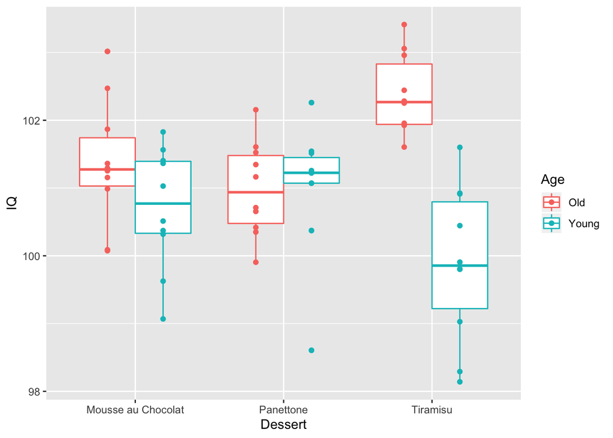

```r
ggplot(Data_IQ, aes(x=Dessert, y=IQ, color=Age))  +
  geom_boxplot(position=position_dodge(0.75)) +
  geom_point(position=position_dodge(width=0.75),aes(group=Age))
```

The interaction seems to be driven by the fact that the difference in IQ between young and old subjects is biggest in the group that likes Tiramisu, compared to the other groups.

To be sure, we run posthoc tests with Bonferroni correction, using the function `emmeans()` from the package with the same name (see [this vignette](https://cran.r-project.org/web/packages/emmeans/vignettes/interactions.html) for details).

```r
library(emmeans)
posthocs <- emmeans(Anova_between, ~ Age|Dessert)
pairs(posthocs, adjust="bon")
```

```
## Dessert = Mousse au Chocolat:
##  contrast    estimate    SE df t.ratio p.value
##  Old - Young   0.6487 0.396 54  1.637  0.1075
##
## Dessert = Panettone:
##  contrast    estimate    SE df t.ratio p.value
##  Old - Young  -0.0309 0.396 54 -0.078  0.9382
##
## Dessert = Tiramisu:
##  contrast    estimate    SE df t.ratio p.value
##  Old - Young   2.4975 0.396 54  6.303  <.0001
```

These posthoc tests confirm our guess: the difference in IQ between young and old people is only significant among Tiramisu lovers (*t*(54)=6.3, *p*<.001). Specifically, Tiramisu seems to benefit the IQ of old people more than that of young people (assuming a causal relationship between dessert eating and IQ).

However, there is also another question we can ask, i.e. if you are young/old, which of these desserts should you prefer? For that we turn around the posthoc formula.

```r
library(emmeans)
posthocs <- emmeans(Anova_between, ~ Dessert|Age)
pairs(posthocs, adjust="bon")
```

```
## Age = Old:
##  contrast                       estimate    SE df t.ratio p.value
##  Mousse au Chocolat - Panettone    0.374 0.396 54  0.943  1.0000
##  Mousse au Chocolat - Tiramisu    -1.026 0.396 54 -2.588  0.0371
##  Panettone - Tiramisu             -1.399 0.396 54 -3.531  0.0026
##
## Age = Young:
##  contrast                       estimate    SE df t.ratio p.value
##  Mousse au Chocolat - Panettone   -0.306 0.396 54 -0.772  1.0000
##  Mousse au Chocolat - Tiramisu     0.823 0.396 54  2.078  0.1275
##  Panettone - Tiramisu              1.129 0.396 54  2.849  0.0186
##
## P value adjustment: bonferroni method for 3 tests
```

It turns out that among old people Tiramisu lovers have a significantly higher IQ compared to both Panettone and Mousse au Chocolat afficionados (*t*(54)=-3.5 and -2.6, *p*=.003 and ..04). These latter two groups do not differ in IQ (*t*(54)=.9, *p*=1).

Young people, on the other hand, should stay away from Tiramisu, especially compared to Panettone (*t*(54)=2.8, *p*=.02).

## Within-subjects and Mixed ANOVA

Here the error term is represented by subject error divided by the within-subjects error.

Let’s test if the weight of chickens depends on their diet and Time (day) of measurement. But first we change the IVs and the variable including the subjects (chicken) into factors.

```r
ChickWeight$Time <- as.factor(ChickWeight$Time)
class(ChickWeight$Time)
```

```
## [1] "factor"
```

```r
class(ChickWeight$Diet)
```

```
## [1] "factor"
```

Now we are ready to run an ANOVA.  
In the error term we include the variable specifying the “subjects” (here the Chicks) divided by all the within-subjects IVs.  
Diet differed between Chicks, so that is a between-subjects factor and should not go into the Error term.  
To obtain the effect size measure partial eta squared, include `anova_table = list(es="pes"))`

```r
Anova_within <- aov_car(weight ~ Diet * Time + Error(Chick/Time), data = ChickWeight, anova_table = list(es="pes"))
```

```
## Contrasts set to contr.sum for the following variables: Diet
```

```r
knitr::kable(nice(Anova_within))
```

| Effect | df | MSE | F | pes | p.value |
| --- | --- | --- | --- | --- | --- |
| Diet | 3, 41 | 7646.22 | 5.07 ** | .27 | .004 |
| Time | 1.26, 51.48 | 5736.71 | 280.95 *** | .87 | <.0001 |
| Diet:Time | 3.77, 51.48 | 5736.71 | 3.77 * | .22 | .01 |

The output tells us that 5 Chicks were measured less often (fewer lines in the variable Time), and were removed from the ANOVA.  
Significant main effects for Diet (*F*(3,41)=5.07, *p*=.004, *pes*=.27), and Time (*F*(1.26,51.48)=280.95, *p*<.001, *pes*=.87) were found. The Diet X Time interaction was also significant (*F*(3.77, 51.48)=3.77, *p*=.01, *pes*=.22).  
Due to correction of the violation of the sphericity assumption, the degrees of freedom for Time and Diet X Time are not integers.

To display boxplots of weight by diet and time (a little crowded plot):

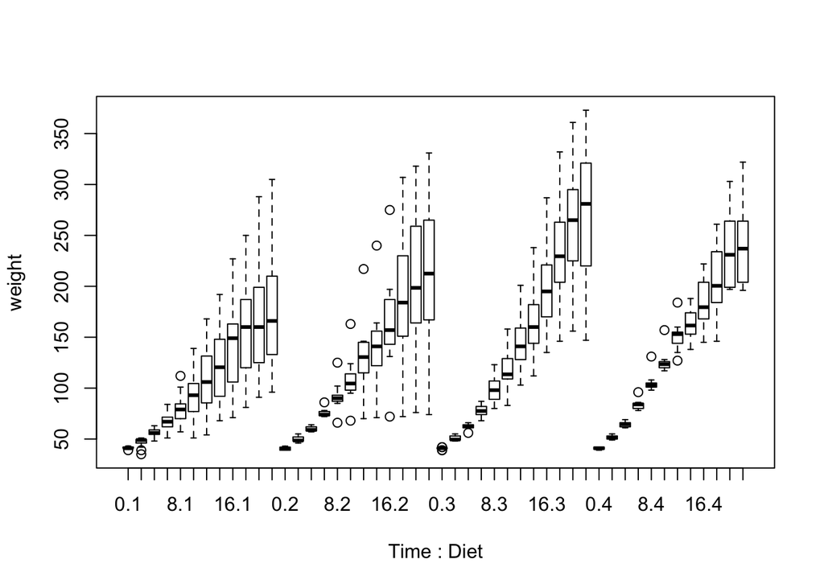

```r
boxplot(weight ~ Time*Diet, data=ChickWeight)
```

Of course we would have to run a lot of posthoc tests here.

Maybe the most interesting is to compare at each time point the weight across diets.

```r
library(emmeans)
posthocs <- emmeans(Anova_within, ~ Diet|Time)
pairs(posthocs, adjust="bon")
```

```
## Time = X0:
##  contrast estimate   SE  df t.ratio p.value
##  1 - 2      0.8625 14.2 143  0.061  1.0000
##  1 - 3      0.7625 14.2 143  0.054  1.0000
##  1 - 4      0.6736 14.7 143  0.046  1.0000
##  2 - 3     -0.1000 15.7 143 -0.006  1.0000
##  2 - 4     -0.1889 16.2 143 -0.012  1.0000
##  3 - 4     -0.0889 16.2 143 -0.006  1.0000
##
## Time = X2:
##  contrast estimate   SE  df t.ratio p.value
##  1 - 2     -1.5250 14.2 143 -0.108  1.0000
##  1 - 3     -2.5250 14.2 143 -0.178  1.0000
##  1 - 4     -4.0139 14.7 143 -0.274  1.0000
##  2 - 3     -1.0000 15.7 143 -0.064  1.0000
##  2 - 4     -2.4889 16.2 143 -0.154  1.0000
##  3 - 4     -1.4889 16.2 143 -0.092  1.0000
##
## Time = X4:
##  contrast estimate   SE  df t.ratio p.value
##  1 - 2     -3.1125 14.2 143 -0.219  1.0000
##  1 - 3     -5.5125 14.2 143 -0.389  1.0000
##  1 - 4     -7.7569 14.7 143 -0.529  1.0000
##  2 - 3     -2.4000 15.7 143 -0.153  1.0000
##  2 - 4     -4.6444 16.2 143 -0.287  1.0000
##  3 - 4     -2.2444 16.2 143 -0.139  1.0000
##
## Time = X6:
##  contrast estimate   SE  df t.ratio p.value
##  1 - 2     -7.7125 14.2 143 -0.544  1.0000
##  1 - 3    -10.2125 14.2 143 -0.720  1.0000
##  1 - 4    -15.9792 14.7 143 -1.090  1.0000
##  2 - 3     -2.5000 15.7 143 -0.159  1.0000
##  2 - 4     -8.2667 16.2 143 -0.511  1.0000
##  3 - 4     -5.7667 16.2 143 -0.357  1.0000
##
## Time = X8:
##  contrast estimate   SE  df t.ratio p.value
##  1 - 2    -10.1375 14.2 143 -0.715  1.0000
##  1 - 3    -16.8375 14.2 143 -1.187  1.0000
```

[output cut: 54 more lines]

```
##  1 - 4    -60.6389 14.7 143 -4.137  0.0004
##  2 - 3    -53.3000 15.7 143 -3.388  0.0055
##  2 - 4    -28.2889 16.2 143 -1.750  0.4933
##  3 - 4     25.0111 16.2 143  1.547  0.7438
##
## Time = X21:
##  contrast estimate   SE  df t.ratio p.value
##  1 - 2    -36.9500 14.2 143 -2.606  0.0608
##  1 - 3    -92.5500 14.2 143 -6.527  <.0001
##  1 - 4    -60.8056 14.7 143 -4.149  0.0003
##  2 - 3    -55.6000 15.7 143 -3.534  0.0033
##  2 - 4    -23.8556 16.2 143 -1.476  0.8529
##  3 - 4     31.7444 16.2 143  1.964  0.3088
##
## P value adjustment: bonferroni method for 6 tests
```

It therefore seems that Diet 3 makes the chicken gain more weight, at least if you can wait 21 days.

Personally, I would have analyzed these data using a linear regression, which allows to test the speed of weight gain across diets. For that, Time needs to be numeric.

```r
ChickWeight$Time <- as.numeric(levels(ChickWeight$Time))[ChickWeight$Time]
chicken_lm <- lm(weight ~ Diet * Time, data = ChickWeight)
car::Anova(chicken_lm)
```

```
## Anova Table (Type II tests)
##
## Response: weight
##            Sum Sq  Df  F value    Pr(>F)
## Diet       129876   3   37.302 < 2.2e-16 ***
## Time      2016357   1 1737.367 < 2.2e-16 ***
## Diet:Time   80804   3   23.208 3.474e-14 ***
## Residuals  661532 570
## ---
## Signif. codes:  0 '***' 0.001 '**' 0.01 '*' 0.05 '.' 0.1 ' ' 1
```

There is a significant Diet X Time interaction, and the line plot suggests that the chickens receiveing diet 3 grow the fastest (but might start off slightly lower).

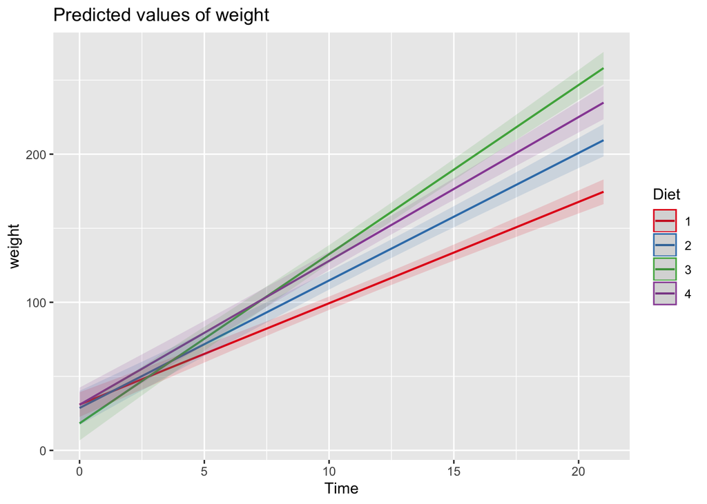

```r
library(sjPlot)
plot_model(chicken_lm, type = "pred", terms = c("Time", "Diet"))
```

Statistically, we can compare these slopes using `lstrends()`:

```r
library(emmeans)
my_slopes <- emmeans::lstrends(chicken_lm, pairwise ~ Diet, var = "Time")
summary(my_slopes, infer=c(T,T), null=0, adjust = "bonf")
```

```
## $lstrends
##  Diet Time.trend    SE  df lower.CL upper.CL t.ratio p.value
##  1          6.84 0.341 570     5.99     7.70 20.076  <.0001
##  2          8.61 0.459 570     7.46     9.76 18.757  <.0001
##  3         11.42 0.459 570    10.27    12.57 24.887  <.0001
##  4          9.71 0.467 570     8.54    10.88 20.802  <.0001
##
## Confidence level used: 0.95
## Conf-level adjustment: bonferroni method for 4 estimates
## P value adjustment: bonferroni method for 4 tests
##
## $contrasts
##  contrast estimate    SE  df lower.CL upper.CL t.ratio p.value
##  1 - 2       -1.77 0.572 570   -3.281   -0.254 -3.092  0.0125
##  1 - 3       -4.58 0.572 570   -6.095   -3.068 -8.014  <.0001
##  1 - 4       -2.87 0.578 570   -4.403   -1.342 -4.969  <.0001
##  2 - 3       -2.81 0.649 570   -4.532   -1.095 -4.335  0.0001
##  2 - 4       -1.11 0.655 570   -2.839    0.628 -1.688  0.5518
##  3 - 4        1.71 0.655 570   -0.025    3.442  2.609  0.0559
##
## Confidence level used: 0.95
## Conf-level adjustment: bonferroni method for 6 estimates
## P value adjustment: bonferroni method for 6 tests
```

The first part of this output called “$lstrends” tells us that the increase in weight across Time is greater than 0 for all 4 diets.

The second part of the output called “$contrasts”, is what we are really after: it compares the steepness of the slopes for the different Diets. Diet 3 is the only one that is significantly steeper than all others (although the comparison with diet 4 has a p = .06, so that is a trend and not statistically significant).